# Praca domowa 3

Mateusz Kwiatkowski

## Wstęp

Jedna z podstawowych zasad związanych z prezentacją danych mówi, że łatwiej czyta się wykresy słupkowe niż kołowe. W tej pracy postanowiłem zbadać ten temat. Szesnastu ankietowanych dostało do wykonania 4 zadania. W każdym z nich musieli opowiedzieć na pytanie dotyczące danych przestawionych na wykresie kołowym, a następnie dostawali te same dane pokazane na wykresie słupkowym i byli ponownie poproszeni o odpowiedź. Wszystkie wykresy zostały wykonane przeze mnie w RStudiu, na podstawie statystyk z różnych rozgrywek sportowych. Na początku opowiem krótko o ankietowanych, a potem przejdę do analizy wyników.

## Opis ankietowanych

Ankieta została przeprowadzona na szesnastu osobach z przedziału wiekowego 10-59. Najliczniejszą grupą byli studenci, jednak nie stanowili oni nawet połowy ankietowanych, dlatego nie możemy mówić o żadnej grupie jako dominującej. Osoby biorące udział w badaniu znacząco różnią się zarówno wiekiem, jak i wykształceniem.

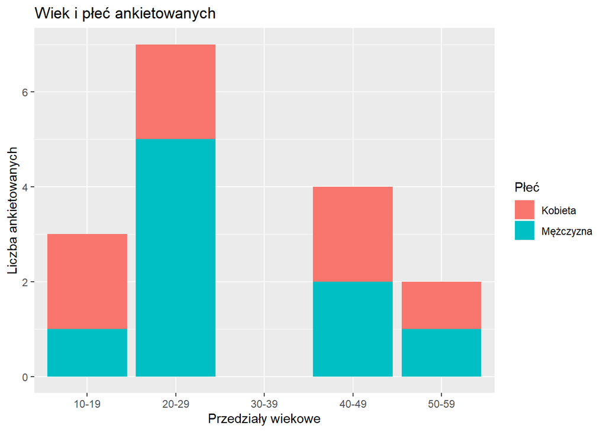

## Treści pytań i wyniki

### Zadanie 1

Treść pierwszego zadania brzmiała: “Uszereguj kraje pod względem liczby zwysięstw w Pucharze Narodów w ciągu ostatnich dwudziestu lat”. Celem zadania było sprawdzenie, czy ankietowani potrafią odczytać podstawowe dane z prostego wykresu kołowego i słupkowego. Wszyscy udzielili poprawnej odpowiedzi.

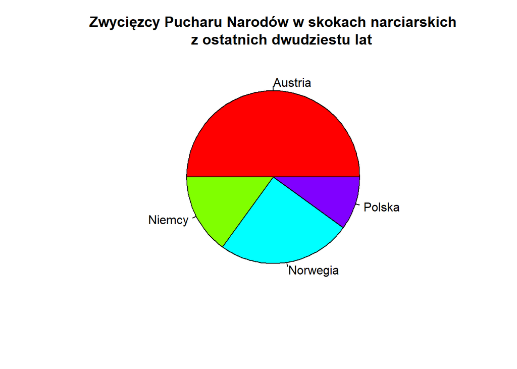

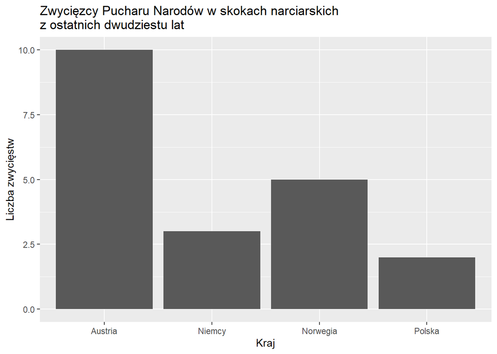

### Zadanie 2

W tym zadaniu postanowiłem podnieść poziom trudności i przedstawić na wykresach więcej danych, o wartościach bardziej zbliżonych do siebie. Wykorzystałem do tego statystykę strzelonych bramek w poprzednim sezonie ligi piłkarskiej w San Marino. Polecenie brzmiało: “Uszereguj zespoły względem liczby strzelonych goli (Podpowiedź: są dwa remisy)”. Dodatkowym uturdnieniem było to, że ankietowani musieli stwierdzić, które zespoły mają takie same wyniki. Na początku dostali oni ten wykres kołowy:

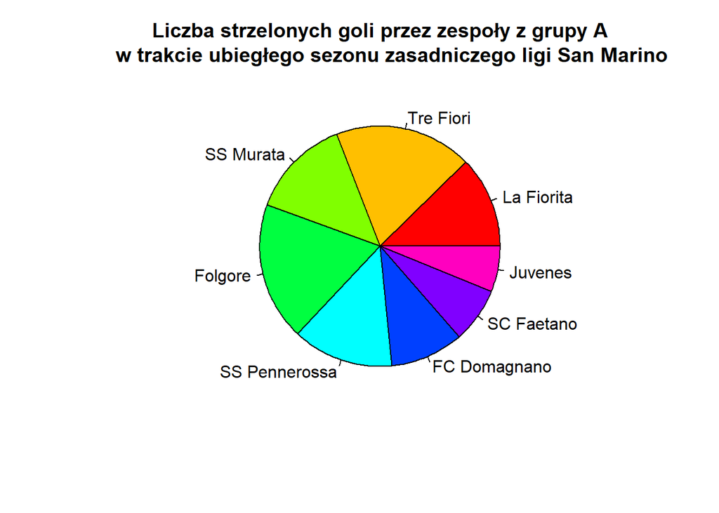

Jak można się było spodziewać, to zadanie poszło zdecydowanie gorzej niż poprzednie.Tylko 7 osób udzieliło poprawnej odpowiedzi. Ankietowani mieli wyraźne problemy ze znalezieniem zespołów o identycznych wynikach i z uszeregowaniem pozostałych. W drugiej części tego zadania sprawdziłem jak poradzą sobie z odczytaniem tych danych z następującego wykresu słupkowego:

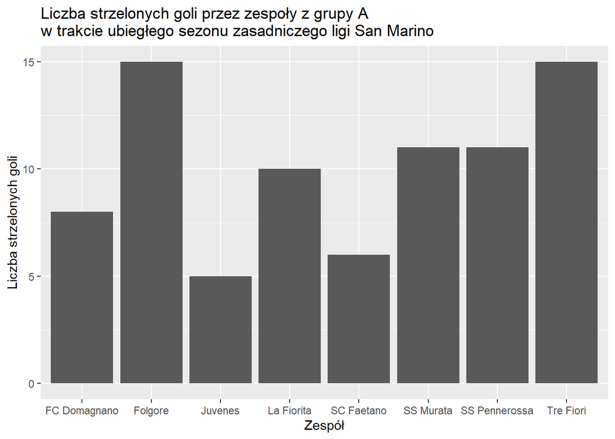

Odczytanie wyników z tego wykresu okazało się znacznie prostsze, ponieważ ankietowani nie mieli żadnych problemów w udzieleniu poprawnych odpowiedzi.

### Zadanie 3

Poprzednie zadanie pokazało, że odczytywanie danych z wykresów kołowych 2D jest trudne. W tej części chciałem sprawdzić jak ankietowani poradzą sobie z interpretowaniem wykresu kołowego 3D. Przedstawiłem na nim stosunek zwycięstw w poprzednim sezonie ligi andorskiej, a pytanie brzmiało: “Uszereguj zespoły względem liczby zwycięstw (Podpowiedź: jest jeden remis)”.

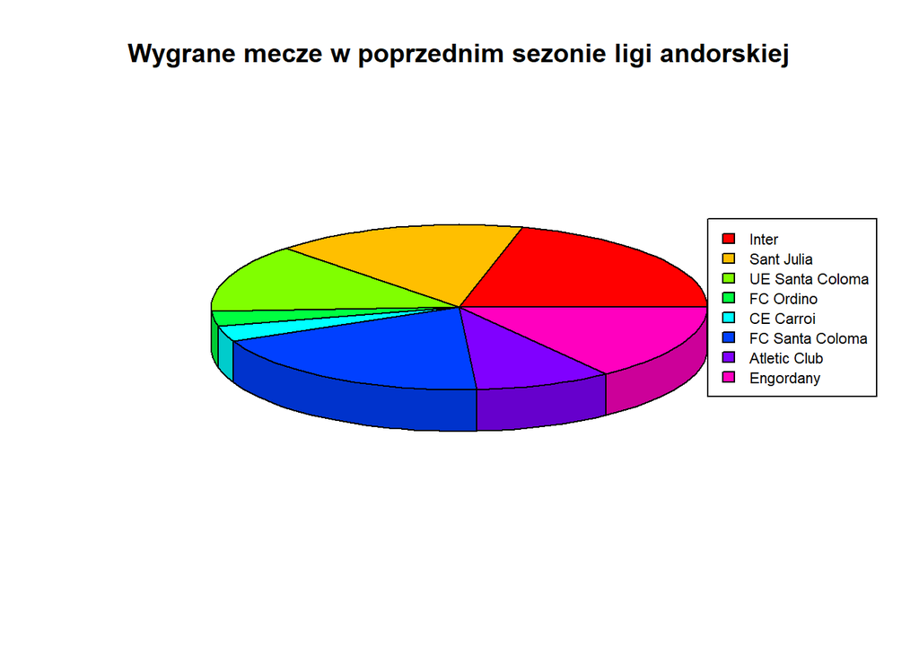

Tak jak w poprzednim zadaniu, ankietowani mieli problemy z udzieleniem odpowiedzi. Zadanie udało się sześciu z nich. Największe trudności mieli ze wskazaniem remisu oraz z uszeregowaniem pierwszej piątki. Te same dane przedstawiłem na wykresie słupkowym i dałem im możliwość zmienienia odpowiedzi:

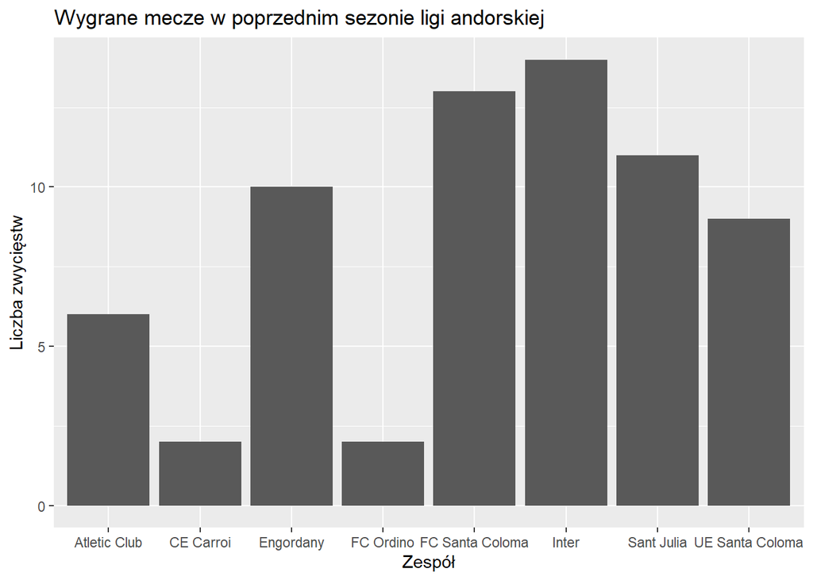

Zadanie w tej wersji udało się wszystkim.

### Zadanie 4

Na koniec zostawiłem najtrudniejsze zadanie. Na wykresach pokazałem liczbę zdobytych punktów w urugwajskiej lidze koszykówki. Każdy zespół zdobył ponad 150 punktów, a różnice między niektórymi drużynami są jednocyfrowe. Spodziewałem się, że ankietowani nie będą w stanie poprawnie odczytać informacji z wykresu kołowego. Treść zadania była sformułowana następująco: “Uszereguj zespoły pod względem liczby zdobytych punktów (Podpowiedź: jest jeden remis)”.

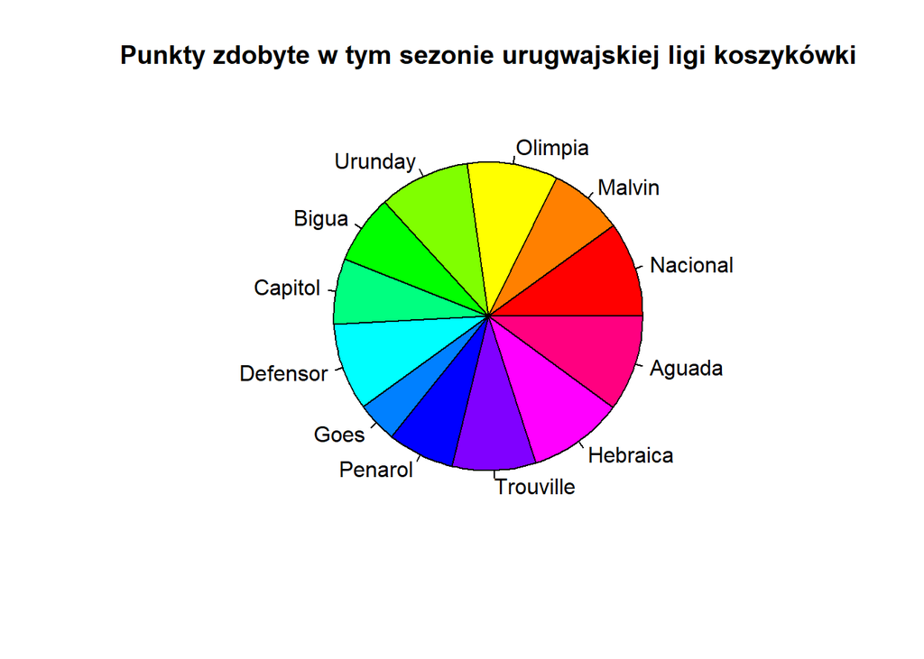

Moje przypuszczenia okazały się słuszne. Uszeregowanie zespołów przy tak niewielkich różnicach dla zdecydowanej większości ludzi okazało się niemożliwe. Tylko jedna osoba udzieliła poprawnej odpowiedzi. Ten test przeprowadziłem również dla wykresu słupkowego.

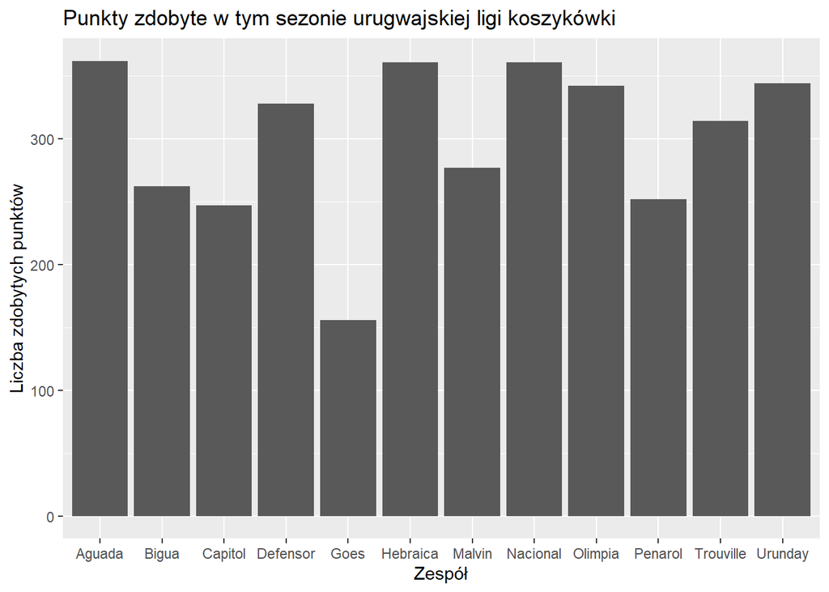

W tym przypadku również nie obyło się bez problemów, jednak zadanie udało się dziewięciu osobom. Różnica między wynikami dla dwóch różnych form wizualizacji była zatem duża.

## Podsumowanie

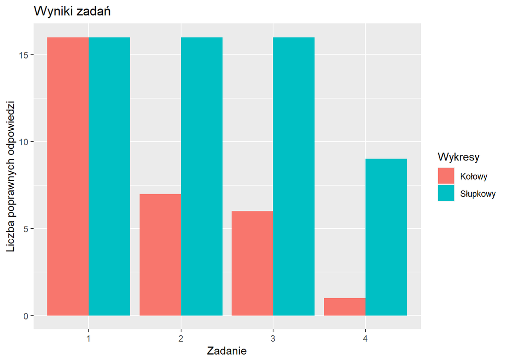

Wyniki jasno pokazują, że ankietowani lepiej radzą sobie w czytaniu wykresów słupkowych niż kołowych, co potwierdza tezę. Gdy różnice między danymi są spore to obie formy wizualizacji są proste do interpretacji. Jeśli jednak różnice są niewielkie to odczytywanie informacji z wykresu słupkowego jest znacznie prostsze, ponieważ dostrzeżenie drobnych detali na wykresie kołowym jest praktycznie niemożliwe.